# Clean self-report data

Dani Cosme

2021-11-08

This document provides the code for the analyses reported in:

[Cosme et al. (Preprint) Testing the adolescent social reorientation model using hierarchical growth curve modeling with parcellated fMRI data](https://psyarxiv.com/8eyf5/)

This script cleans the self-report data for the analyses reported in supplementary material.

# load packages

```r
library(tidyverse)
library(psych)
```

# load SPPC data

- Recode 9999 and multiple responses as NA

```r
t1_sppc = readxl::read_excel("/Volumes/psych-cog/dsnlab/SFIC_data_sheets/lerner/T1Lerner_Enter-Check_AT.xls", sheet = "What I am like") %>%
  extract(SID, "subjectID", "L[0-3]{1}([0-9]{2})") %>%
  mutate(subjectID = paste0("s0", subjectID),
         wave = "t1") %>%
  gather(question, value, starts_with("Q")) %>%
  mutate(value = ifelse(value %in% c("9999", "1,3", "2,3", "2,4"), NA, value)) %>%
  spread(question, value) %>%
  select(-`...38`)

t2_sppc = readxl::read_excel("/Volumes/psych-cog/dsnlab/SFIC_data_sheets/lerner/T2Lerner_Enter-Check_AT.xls", sheet = "What I Am Like") %>%
  filter(!is.na(SID)) %>%
  extract(SID, "subjectID", "L[0-3]{1}([0-9]{2})") %>%
  mutate(subjectID = paste0("s0", subjectID),
         wave = "t2") %>%
  gather(question, value, starts_with("Q")) %>%
  mutate(value = ifelse(value %in% c("9999", "2,4"), NA, value)) %>%
  spread(question, value) %>%
  select(-`...38`)

t3_sppc = readxl::read_excel("/Volumes/psych-cog/dsnlab/SFIC_data_sheets/lerner/T3Lerner_Enter-Check_AT.xls", sheet = "What I am like") %>%
  filter(!is.na(SID)) %>%
  extract(SID, "subjectID", "L[0-3]{1}([0-9]{2})") %>%
  mutate(subjectID = paste0("s0", subjectID),
         wave = "t3") %>%
  gather(question, value, starts_with("Q")) %>%
  mutate(value = ifelse(value %in% c("9999", "2,4"), NA, value)) %>%
  spread(question, value)

t2_id = readxl::read_excel("/Volumes/psych-cog/dsnlab/SFIC_data_sheets/lerner/T2Lerner_with_SPPC_ID.xls", sheet = "SPPC ID") %>%
  filter(grepl("^L", SID)) %>%
  extract(SID, "subjectID", "L[0-3]{1}([0-9]{2})") %>%
  mutate(subjectID = paste0("s0", subjectID),
         wave = "t2") %>%
  mutate_at(vars(starts_with("Q")), as.numeric) %>%
  select(subjectID, wave, starts_with("Q"))

t3_id = readxl::read_excel("/Volumes/psych-cog/dsnlab/SFIC_data_sheets/lerner/T3SPPC_ID.xls") %>%
  filter(grepl("^L", SID)) %>%
  extract(SID, "subjectID", "L[0-3]{1}([0-9]{2})") %>%
  mutate(subjectID = paste0("s0", subjectID),
         wave = "t3") %>%
  mutate_at(vars(starts_with("Q")), as.numeric) %>%
  select(subjectID, wave, starts_with("Q"))
```

# bind and score SPPC

- The note on the excels spreadsheets says “1 = first bubble, 2 = second bubble, 3 = third bubble, 4 = fourth bubble”
- Therefore academic items: Q13, Q19, Q31 and social items: Q2, Q14, Q26 are correctly scored (left to right = 1-4)
- The other items academic items: Q1, Q7, Q25 and social items: Q8, Q20, Q32 are incorrectly scored (left to right = 4-1) –> swap these ratings

```r
sppc = bind_rows(t1_sppc, t2_sppc, t3_sppc) %>%
  mutate_at(vars(starts_with("Q")), as.numeric)
```

## check distribution

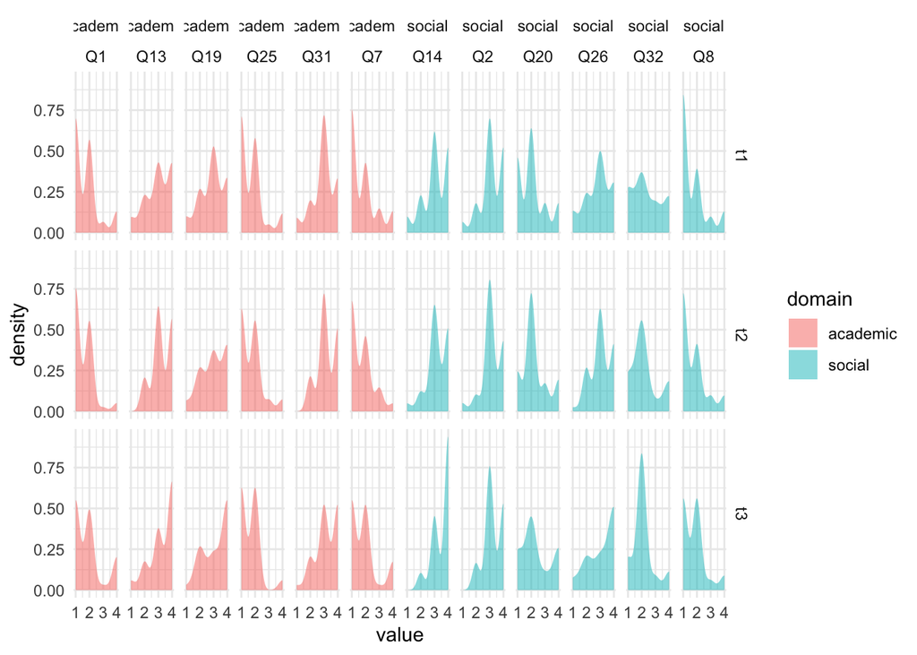

```r
sppc %>%
  select(subjectID, wave, "Q1", "Q7", "Q13", "Q19", "Q25", "Q31", "Q2", "Q8", "Q14", "Q20", "Q26", "Q32") %>%
  gather(item, value, starts_with("Q")) %>%
  mutate(domain = ifelse(item %in% c("Q1", "Q7", "Q13", "Q19", "Q25", "Q31"), "academic", "social")) %>%
  ggplot(aes(value, fill = domain)) +
    geom_density(alpha = .5, color = NA) +
    scale_x_continuous(limits = c(1,4), breaks = c(1:4)) +
    facet_grid(wave~domain + item) +
    theme_minimal()
```

## check reverse scored distribution

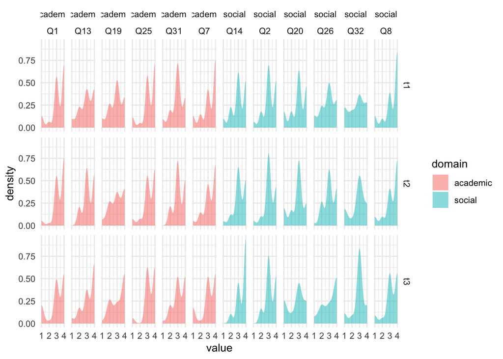

```r
sppc %>%
  select(subjectID, wave, "Q1", "Q7", "Q13", "Q19", "Q25", "Q31", "Q2", "Q8", "Q14", "Q20", "Q26", "Q32") %>%
  gather(item, value, starts_with("Q")) %>%
  mutate(domain = ifelse(item %in% c("Q1", "Q7", "Q13", "Q19", "Q25", "Q31"), "academic", "social"),
         value = ifelse(!item %in% c("Q13", "Q19", "Q31", "Q2", "Q14", "Q26") & value == 4, 1,
                 ifelse(!item %in% c("Q13", "Q19", "Q31", "Q2", "Q14", "Q26") & value == 3, 2,
                 ifelse(!item %in% c("Q13", "Q19", "Q31", "Q2", "Q14", "Q26") & value == 2, 3,
                 ifelse(!item %in% c("Q13", "Q19", "Q31", "Q2", "Q14", "Q26") & value == 1, 4, value))))) %>%
  ggplot(aes(value, fill = domain)) +
    geom_density(alpha = .5, color = NA) +
    scale_x_continuous(limits = c(1,4), breaks = c(1:4)) +
    facet_grid(wave~domain + item) +
    theme_minimal()
```

```r
key_list = list(academic = c("-Q1", "-Q7", "Q13", "Q19", "-Q25", "Q31"),
                social = c("Q2", "-Q8", "Q14", "-Q20", "Q26", "-Q32"),
                self_worth = c("Q6", "Q12", "-Q18", "-Q24", "-Q30", "Q36"))

sppc[39:41] = psych::scoreItems(key_list, sppc[,-c(1:2)], min = 1, max = 4)$scores

sppc = sppc %>%
  rename("academic" = V1,
         "social" = V2,
         "self_worth" = V3) %>%
  select(-starts_with("Q")) %>%
  gather(domain, competence, academic, social, self_worth)
```

## check scored distribution

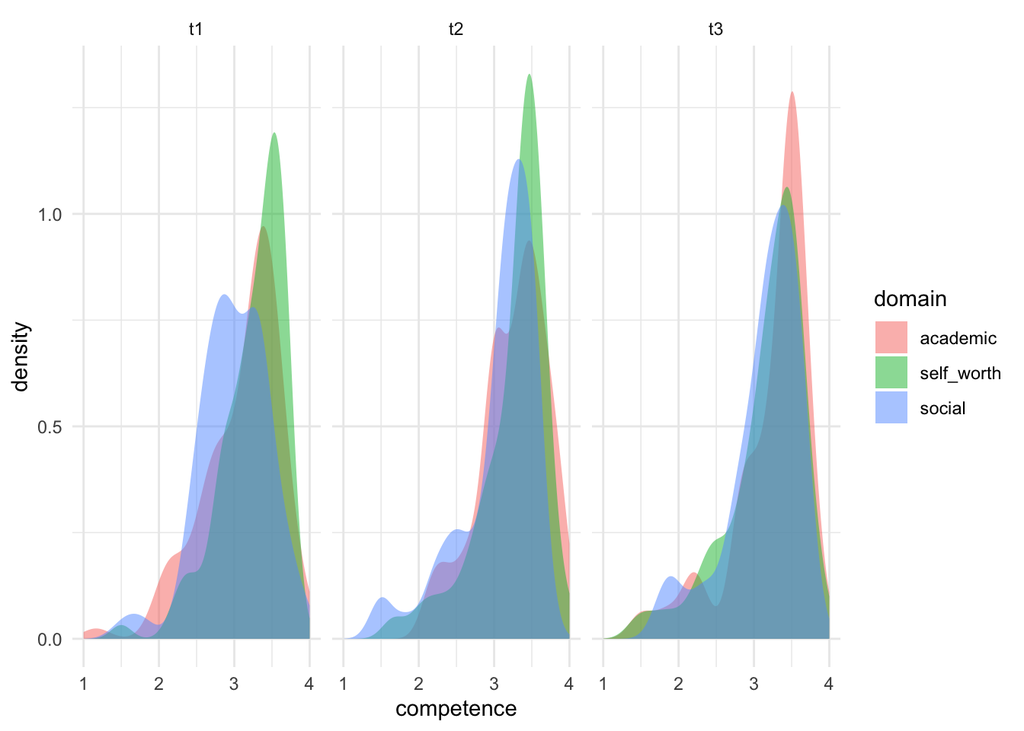

```r
sppc %>%
  ggplot(aes(competence, fill = domain)) +
    geom_density(alpha = .5, color = NA) +
    scale_x_continuous(limits = c(1,4), breaks = c(1:4)) +
    facet_grid(~wave) +
    theme_minimal()
```

# bind and score SPPC ID

- Data appear to be reverse-scored (academic items = Q1, social items = Q7)
- The notes give column values (e.g., left column = 4, 3, right column = 1, 2) and is swapped for reverse scored items (e.g., left column = 1, 2, right column = 4, 3)
- Note the scale for the survey administered in this sample, was swapped for th right column (“really true”, “sort of true” instead of “sort of true”, “really true”)

```r
id = bind_rows(t2_id, t3_id)
```

## check distribution

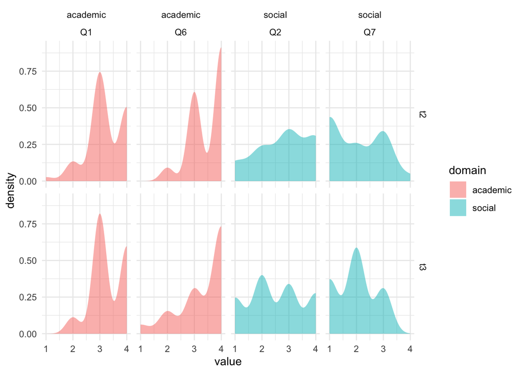

```r
id %>%
  select(subjectID, wave, Q1, Q6, Q2, Q7) %>%
  gather(item, value, starts_with("Q")) %>%
  mutate(domain = ifelse(item %in% c("Q1", "Q6"), "academic", "social")) %>%
  ggplot(aes(value, fill = domain)) +
    geom_density(alpha = .5, color = NA) +
    scale_x_continuous(limits = c(1,4), breaks = c(1:4)) +
    facet_grid(wave~domain + item) +
    theme_minimal()
```

## check reverse scored distribution

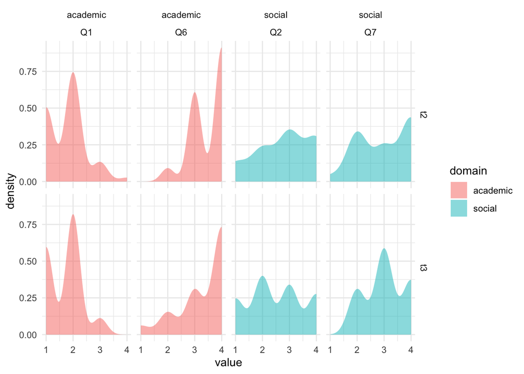

```r
id %>%
  select(subjectID, wave, Q1, Q6, Q2, Q7) %>%
  gather(item, value, starts_with("Q")) %>%
  mutate(domain = ifelse(item %in% c("Q1", "Q6"), "academic", "social"),
         value = ifelse(item %in% c("Q1", "Q7") & value == 4, 1,
                 ifelse(item %in% c("Q1", "Q7") & value == 3, 2,
                 ifelse(item %in% c("Q1", "Q7") & value == 2, 3,
                 ifelse(item %in% c("Q1", "Q7") & value == 1, 4, value))))) %>%
  ggplot(aes(value, fill = domain)) +
    geom_density(alpha = .5, color = NA) +
    scale_x_continuous(limits = c(1,4), breaks = c(1:4)) +
    facet_grid(wave~domain + item) +
    theme_minimal()
```

```r
key_list = list(academic = c("Q1", "Q6"),
                social = c("Q2", "Q7"))

id[13:14] = psych::scoreItems(key_list, id[,-c(1:2)], min = 1, max = 4)$scores

id = id %>%
  rename("academic" = V1,
         "social" = V2) %>%
  select(-starts_with("Q")) %>%
  gather(domain, importance, academic, social)
```

## check scored distribution

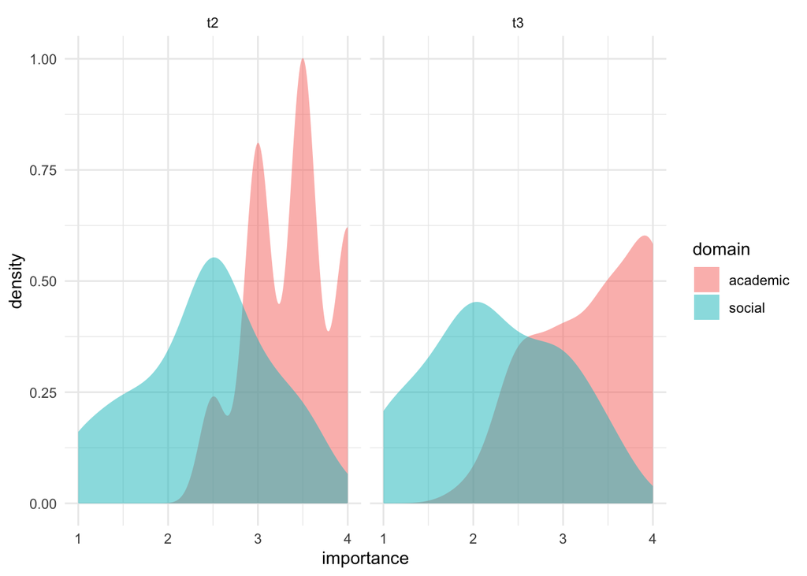

```r
id %>%
  ggplot(aes(importance, fill = domain)) +
    geom_density(alpha = .5, color = NA) +
    scale_x_continuous(limits = c(1,4), breaks = c(1:4)) +
    facet_grid(~wave) +
    theme_minimal()
```

# correlation between sppc and id

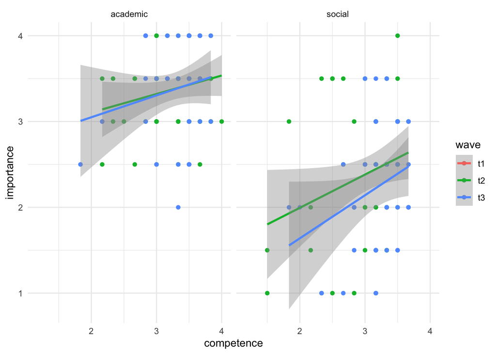

```r
sppc %>%
  left_join(., id, by = c("subjectID", "wave", "domain")) %>%
  filter(!domain == "self_worth") %>%
  select(subjectID, wave, domain, competence, importance) %>%
  ggplot(aes(competence, importance, color = wave)) +
  geom_point() +
  geom_smooth(method = "lm") +
  facet_grid(~domain) +
  theme_minimal()
```

# merge and save

```r
sppc %>%
  left_join(., id, by = c("subjectID", "wave", "domain")) %>%
  select(subjectID, wave, domain, competence, importance) %>%
  saveRDS(., "../../data/sppc.RDS")
```